# Point Process

Diane Lu

June 17, 2020

## Event Time (aligning the first event time)

The color represents species.

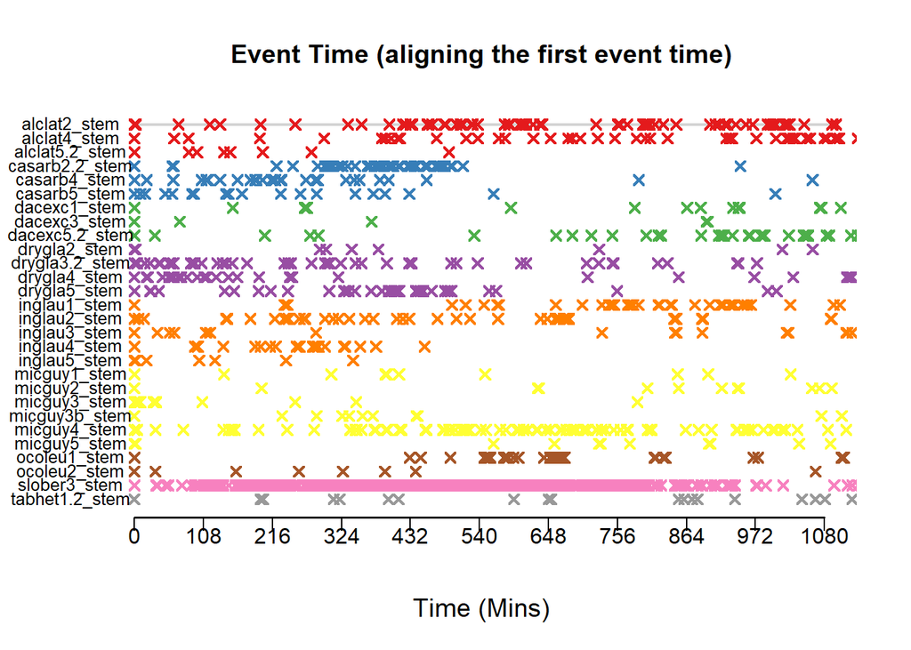

## Poisson Process

Fitting Poisson Process to Each Experiment

Assumes inter-event times are independent. Intensity: expected inter-event times = 1/lambda

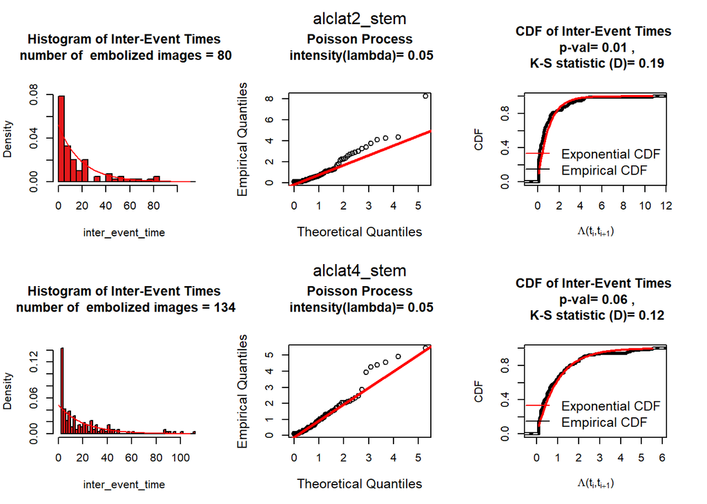

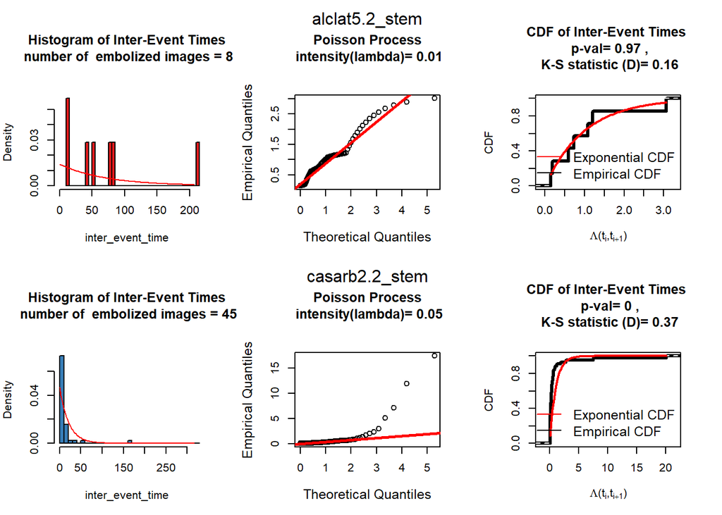

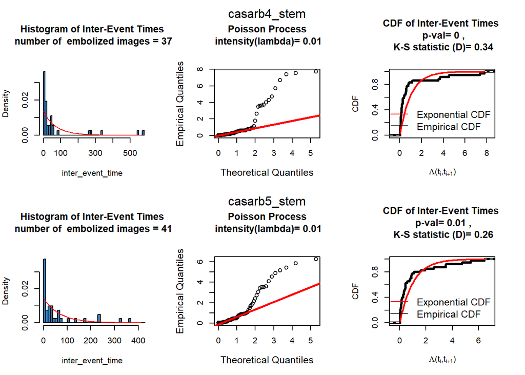

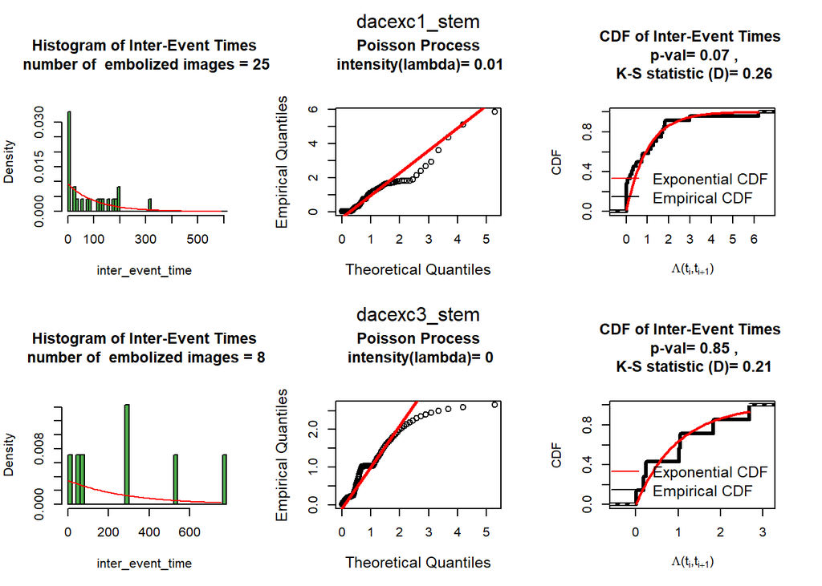

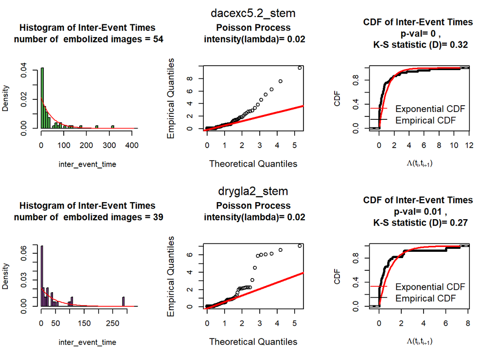

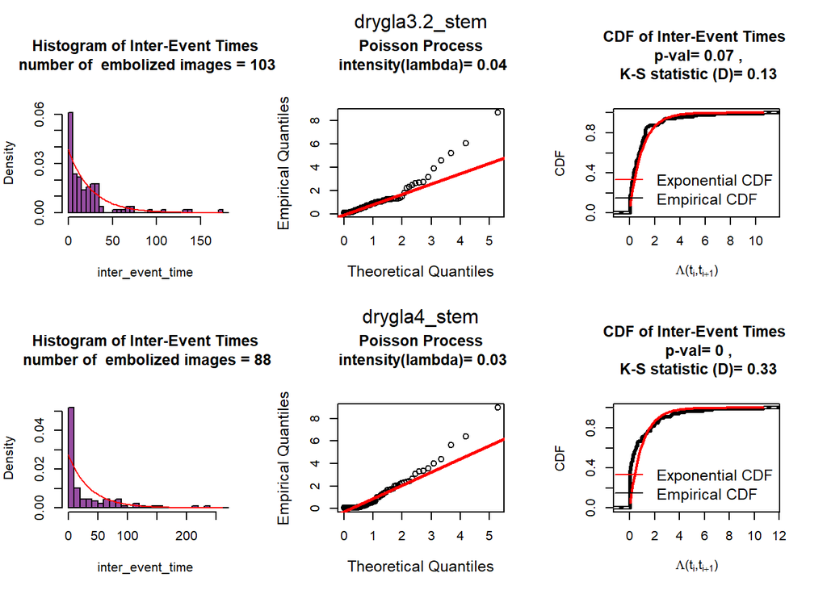

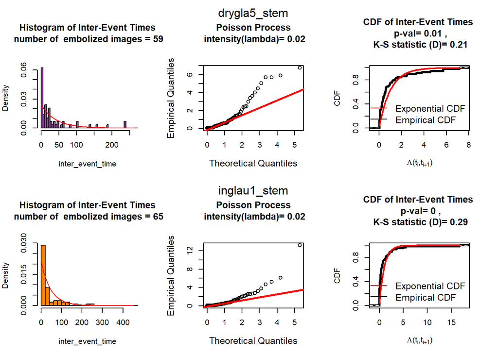

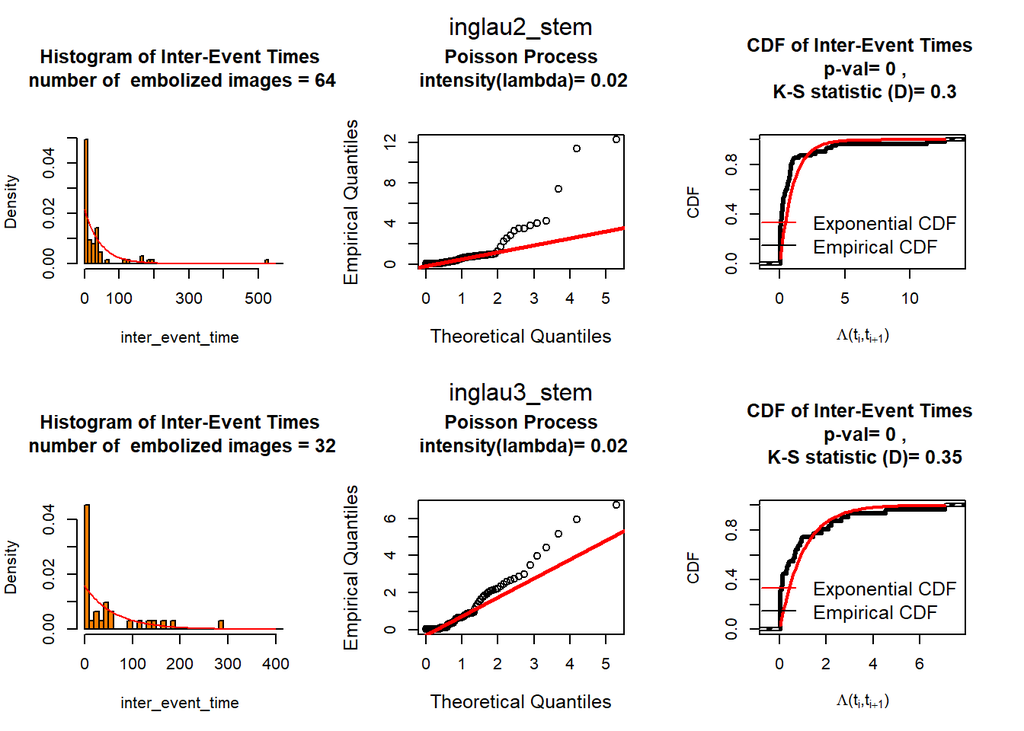

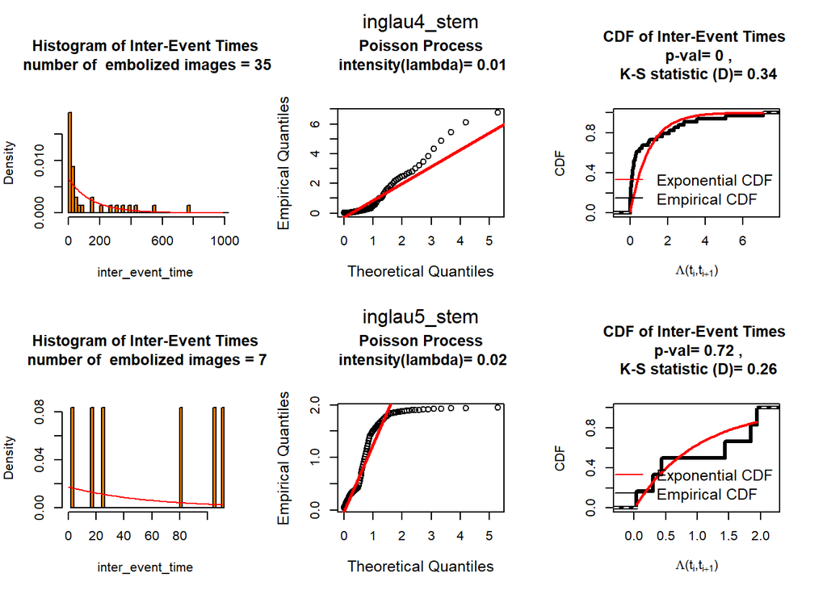

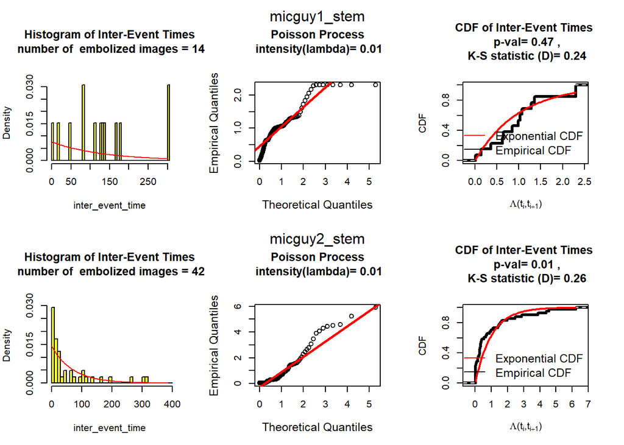

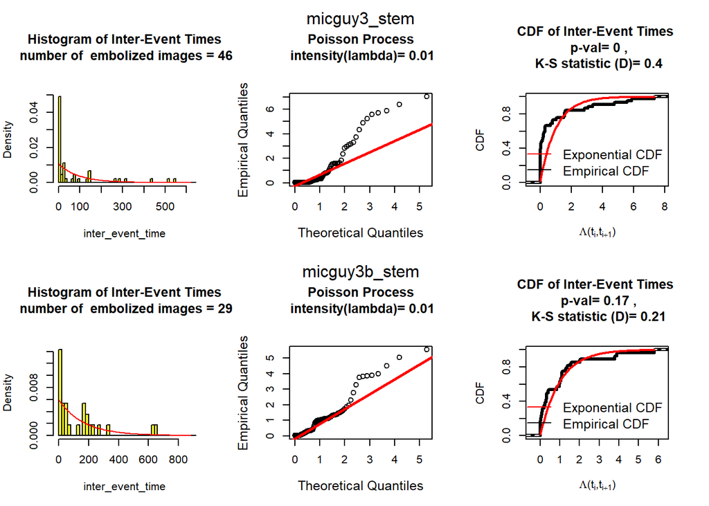

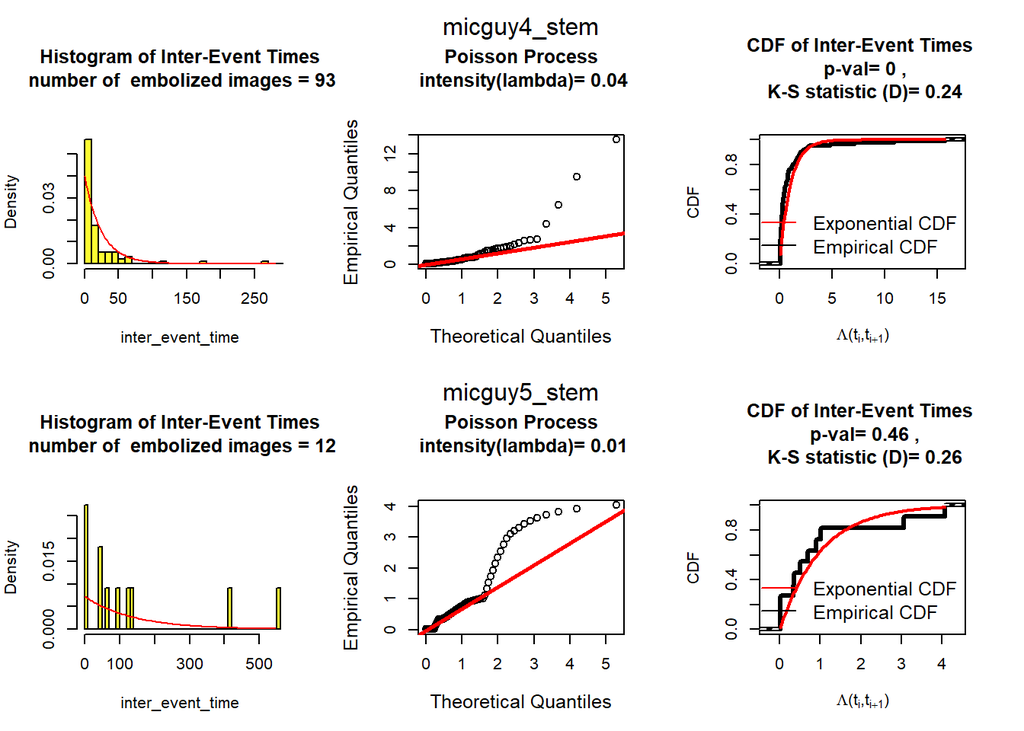

[2 more figures not shown]

QQ plot implying heavy-tailed, probably because is being fitted to a lot of events that are with small inter-event time. (In histogram, the number of small inter-event time is a lot higher than the fitted exponential curve.)

## Hawkes Process

Kernel: exponential decay

Conditional intensity:
$$\lambda(t) = \lambda_0 + \alpha \sum_{i:t_i < t} e^{-\beta(t-t_i)}$$
To ensure conditional intensity is non-negative and the parameters are meaningful, constraints need to be put on the parameter space. That is, $\lambda_0,\alpha \geq 0$ and $\beta > 0$. (If $\beta = 0$, it would result Inf in log-likelihood and other places that does integration.)

*Reference: A Tutorial on Hawkes Processes for Events in Social Media (2017) Eq(1.12)*

Let the observed event time be $\{t_1,...,t_n\}$ and let $N(t)$ denotes the observed numebr of events in time [0,t].

Log likelihood:
$$\begin{aligned}
l(t_1...,t_n) &= - \int_{0}^{t_n} \lambda(t) dt + \int_{0}^{t_n} \log(\lambda(t)) dN(t)\\
&= - \{ \int_{0}^{t_n} \lambda_0 + \int_{0}^{t} \alpha e^{-\beta(t-u)} dN(u) dt \} + \int_{0}^{t_n} \log(\lambda(t)) dN(t)\\
&= -\lambda_0 t_n - \int_{0}^{t_n} \int_{u}^{t_n} \alpha e^{-\beta(t-u)} dt dN(u) + \int_{0}^{t_n} \log(\lambda(t)) dN(t)\\
&= -\lambda_0 t_n + \frac{\alpha}{\beta} \int_{0}^{t_n} e^{-\beta(t_n-u)}-1 dN(u) + \int_{0}^{t_n} \log(\lambda(t)) dN(t)\\
&= -\lambda_0 t_n + \frac{\alpha}{\beta} \sum_{i=1}^{n} (e^{-\beta(t_n-t_i)}-1) + \sum_{i=1}^{n} \log (\lambda_0 + \alpha \sum_{k:t_k < t_i} e^{-\beta(t_i-t_k)})
\end{aligned}$$

Compensator is defined as below
$$\Lambda(t) = \int_{0}^{t} \lambda(u) du$$
and it follows an unit rate Poisson process. Hence, “the durations of the estimated residual process” defined as below follows an unit-rate exponential distribution.

$$\Lambda(t_i,t_{i+1}) = \int_{t_i}^{t_{i+1}} \lambda(u) du$$
Plug in our model for conditional intensity:

$$\begin{aligned}
\Lambda(t_i,t_{i+1}) &= \int_{t_i}^{t_{i+1}} \lambda_0 du + \alpha \int_{t_i}^{t_{i+1}} \sum_{k:t_k < u} e^{-\beta(u-t_k)} du \\
&= \lambda_0 (t_{i+1} - t_i) + \alpha \sum_{k=1}^{i} \int_{t_i}^{t_{i+1}} e^{-\beta(u-t_k)} du \\
&= \lambda_0 (t_{i+1} - t_i) - \frac{\alpha}{\beta} \sum_{k=1}^{i} (e^{-\beta(t_{i+1}-t_k)} - e^{-\beta(t_{i}-t_k)})
\end{aligned}$$

*Reference: Analysis of Order Clustering Using High Frequency Data: A Point Process Approach (2012) (Eq 2.29)*

The residual at time t is defined as below:

$$R(t) = N(t) - \int_{0}^{t} \lambda(u) du$$
The residual at time $t_i$ (Recall: observed event time$=\{ t_1, ..., t_n\}$) is then

$$R(t_i) = N(t_i) - \sum_{j=1}^{i-1} \int_{t_j}^{t_{j+1}} \lambda(u) du$$

Note that the integral is actually the duration of the residual process when i>=2.

*Reference: Residual analysis for spatial point processes by Baddeley, Turner, Moller, and Hazelton (2005)*

The scaled version (Pearson $h(u)=\frac{1}{\sqrt{\lambda(u)}}$):

$$\begin{aligned}
R_P(t_i) &= \sum_{j=1}^{t_i} h(t_i)*1 - \int_{0}^{t_i} h(u) \lambda(u) du \\
&= \sum_{j=1}^{t_i} \frac{1}{\sqrt{{\lambda(t_i)}}} - \int_{0}^{t_i} \sqrt{\lambda(u)} du
\end{aligned}$$

The Pearson residual in the time interval $(t_i,t_{i+1}]$:
$$\begin{aligned}
r_{pearson}(t_i,t_{i+1}) &= \frac{1}{t_{i+1}-t_i}(R_P(t_{i+1}) - R_P(t_{i}))\\
&= \frac{1}{t_{i+1}-t_i}(\frac{1}{\sqrt{{\lambda(t_{i+1})}}} - \int_{t_i}^{t_{i+1}} \sqrt{\lambda(u)} du)
\end{aligned}$$

*Reference: NHPoisson: An R Package for Fitting and Validating Nonhomogeneous Poisson Processes (2013) Eq(3) (4)*

Below, I’ve plotted $\{R(t_i)\}_{i=2}^{n}$ versus inter-event distance. The inter-event distance is currently defined as the difference between centroid column position (averaged in an image, if an image has multiple connected components).

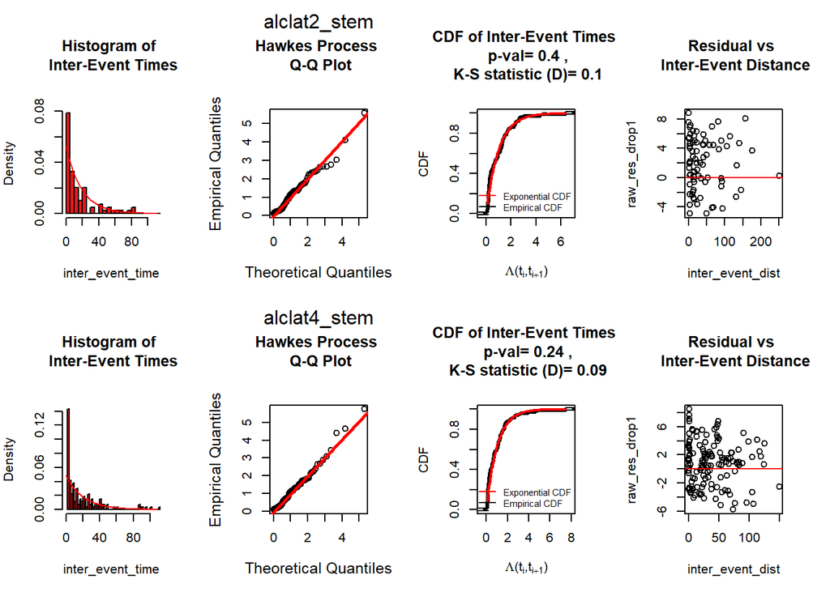

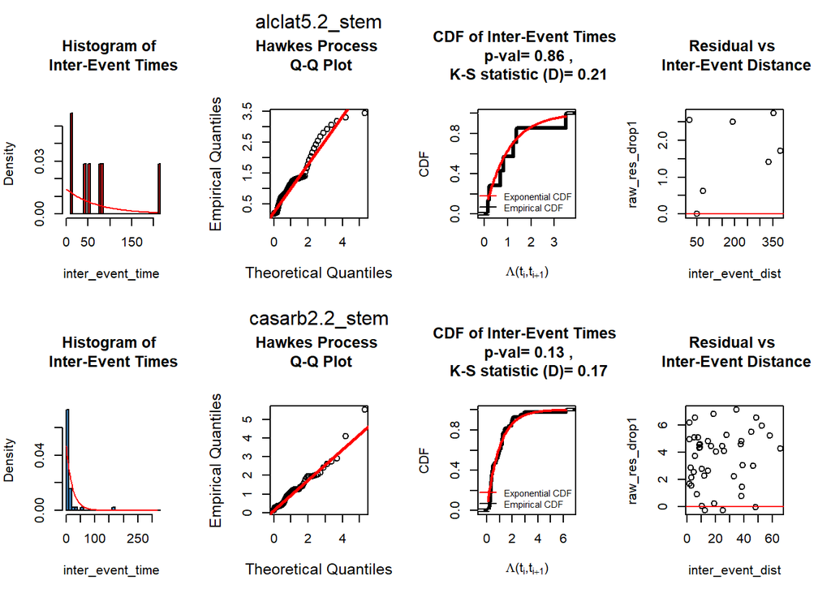

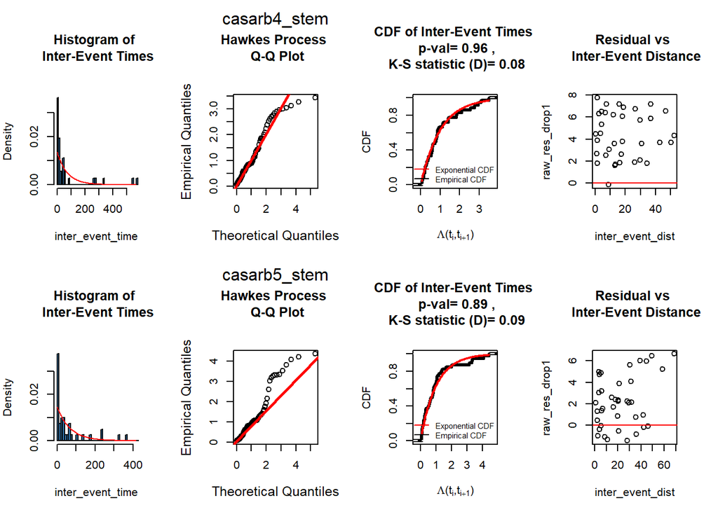

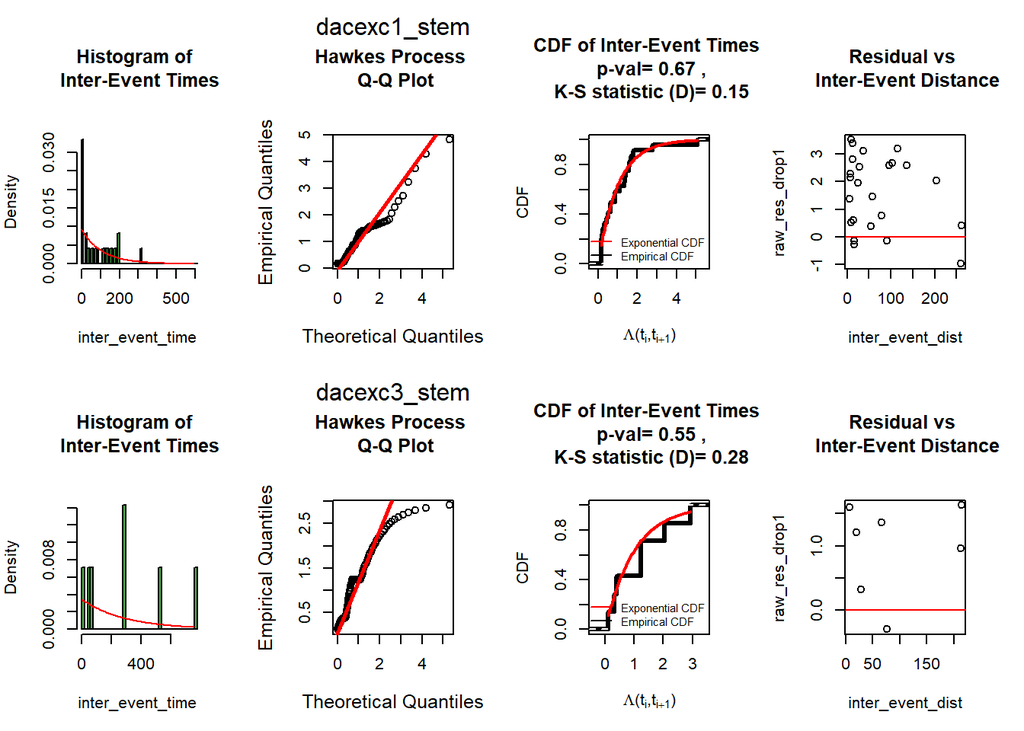

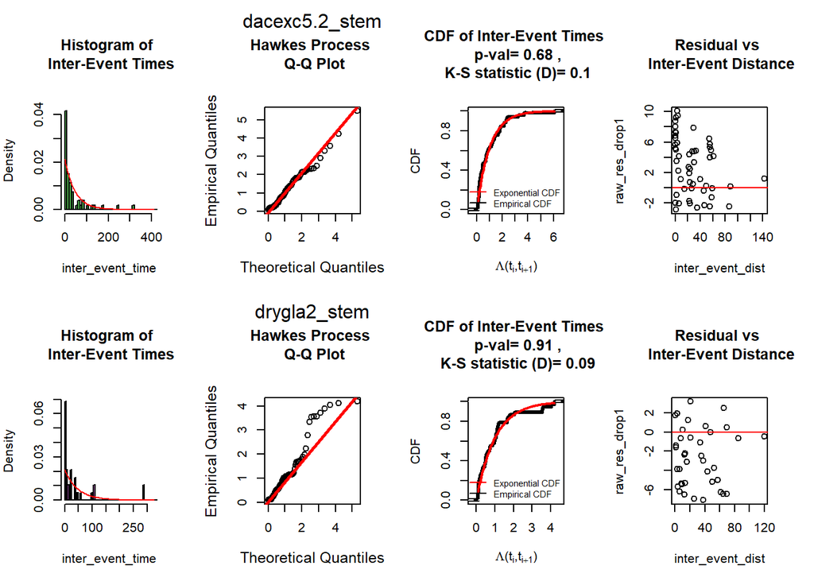

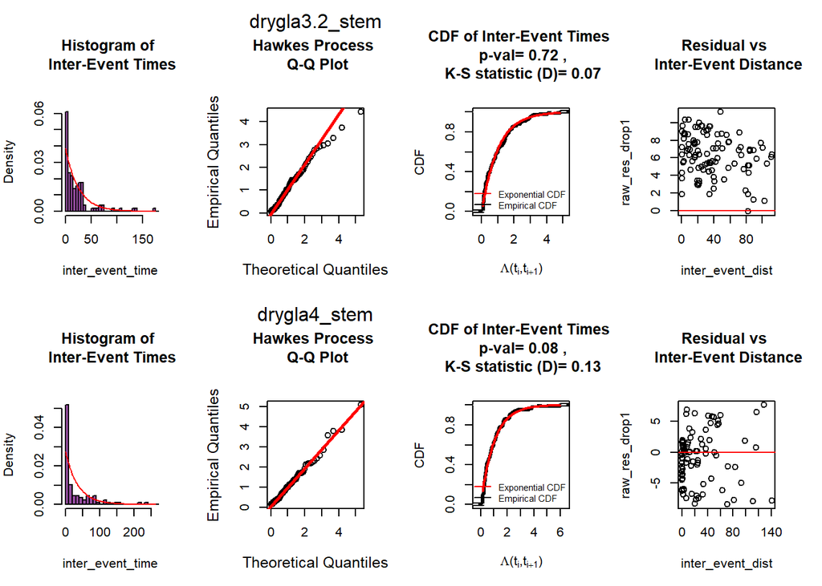

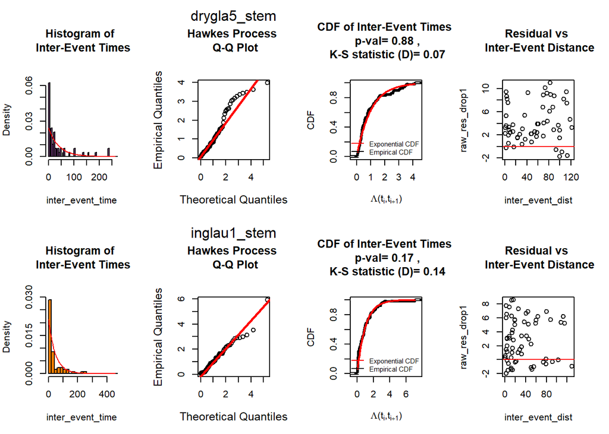

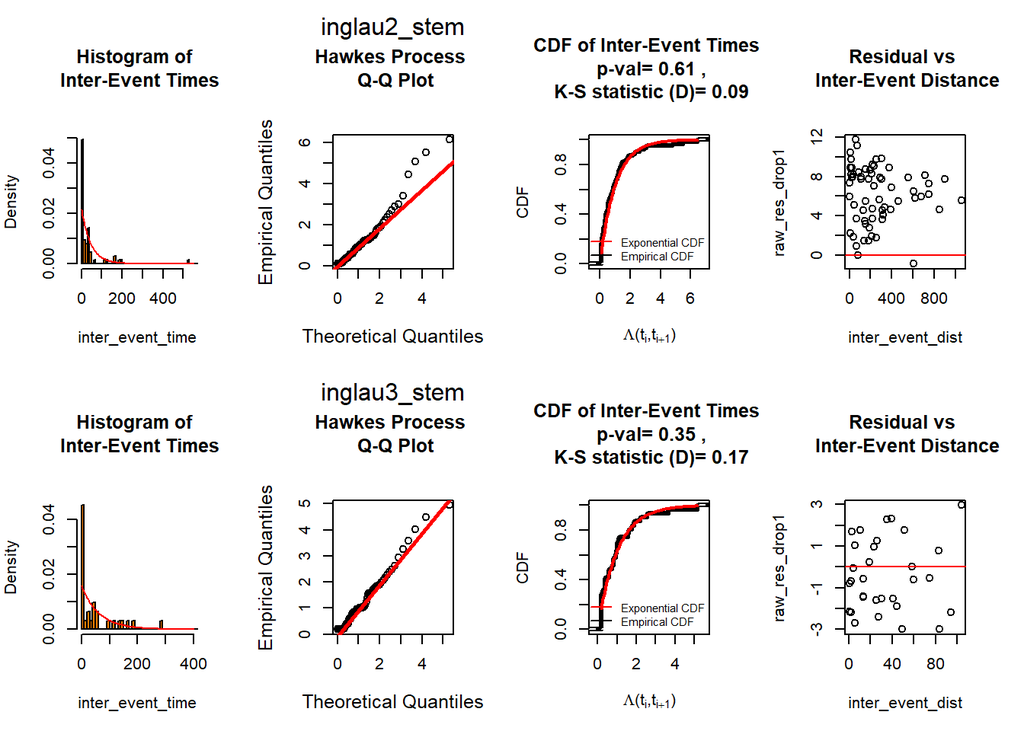

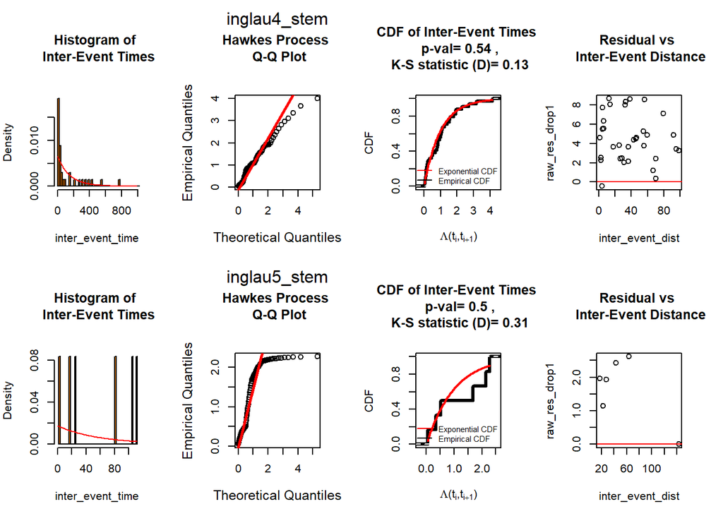

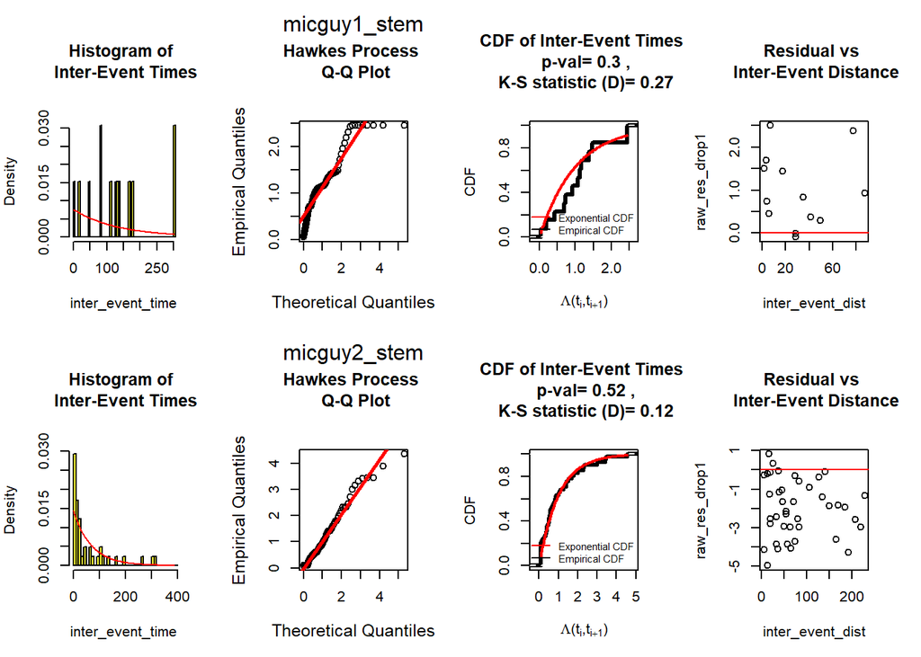

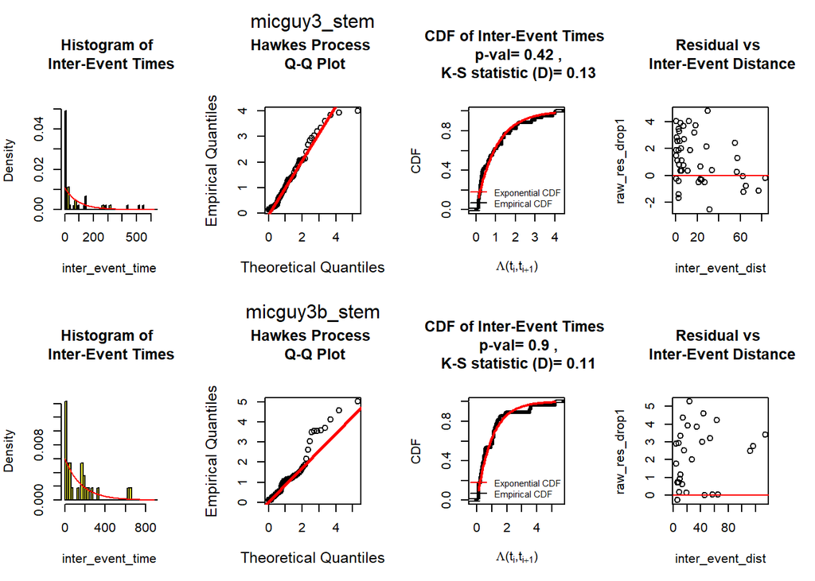

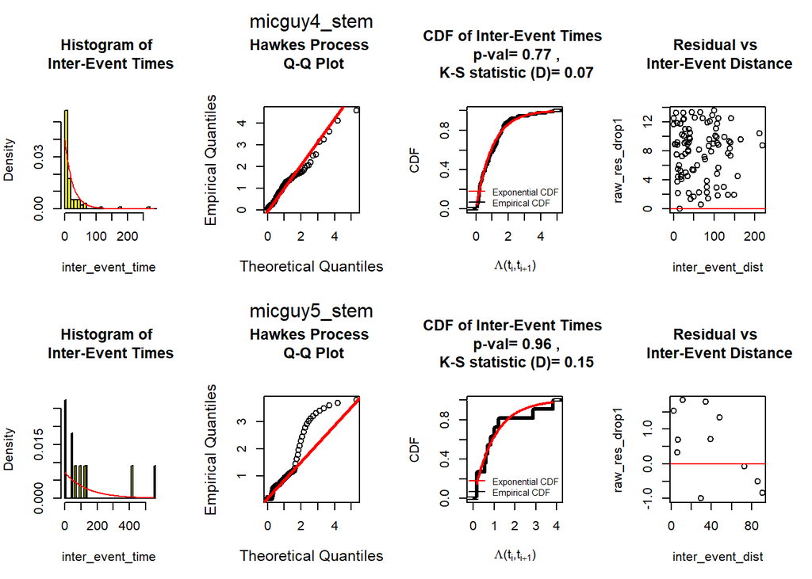

[2 more figures not shown]

```
##                folder_index species num_emb_img     lambda0       alpha
## alclat2_stem              1       1          80 0.025959801 0.027466807
## alclat4_stem              2       1         134 0.020288767 0.004579441
## alclat5.2_stem            3       1           8 0.016261541 0.000000000
## casarb2.2_stem            4       2          45 0.007649651 0.040023978
## casarb4_stem              5       2          37 0.004080924 0.015160858
## casarb5_stem              6       2          41 0.009130567 0.032830350
## dacexc1_stem              7       3          25 0.007162657 0.102930417
## dacexc3_stem              8       3           8 0.003637422 0.105613952
## dacexc5.2_stem            9       3          54 0.009960365 0.038186463
## drygla2_stem             10       4          39 0.010605269 0.036107685
## drygla3.2_stem           11       4         103 0.014856670 0.010924955
## drygla4_stem             12       4          88 0.014039679 0.066519914
## drygla5_stem             13       4          59 0.010634273 0.017575296
## inglau1_stem             14       5          65 0.008194664 0.026526540
## inglau2_stem             15       5          64 0.009010898 0.038432070
## inglau3_stem             16       5          32 0.010713235 0.106334413
## inglau4_stem             17       5          35 0.003115792 0.014732093
## inglau5_stem             18       5           7 0.020473029 0.000000000
## micguy1_stem             19       6          14 0.008004870 0.020585028
## micguy2_stem             20       6          42 0.009718758 0.036863832
## micguy3_stem             21       6          46 0.005118829 0.068704492
## micguy3b_stem            22       6          29 0.005098115 0.065305909
## micguy4_stem             23       6          93 0.007224429 0.012499565
## micguy5_stem             24       6          12 0.006265528 0.119587503
## ocoleu1_stem             25       7          58 0.006271807 0.107221785
## ocoleu2_stem             26       7          37 0.002341372 0.030708300
## slober3_stem             27       8         441 0.025562171 0.022149943
## tabhet1.2_stem           28       9          76 0.016931583 0.037383734
##                       beta    KS_pval       KS_D converge not_few_emb
## alclat2_stem   0.053475462 0.39787237 0.09879056        1         1.0
## alclat4_stem   0.007419894 0.23522141 0.08966812        1         1.0
## alclat5.2_stem 1.017064076 0.86302857 0.20917857        1         0.2
## casarb2.2_stem 0.046669186 0.12926487 0.17251106        1         1.0
## casarb4_stem   0.020753484 0.95882581 0.08055691        1         1.0
## casarb5_stem   0.081448903 0.88619735 0.08840256        1         1.0
## dacexc1_stem   0.368888174 0.67091733 0.14779589        1         1.0
## dacexc3_stem   0.747454652 0.55074948 0.27987303        1         0.2
## dacexc5.2_stem 0.069573292 0.67925389 0.09583341        1         1.0
## drygla2_stem   0.069183539 0.91262650 0.08690471        1         1.0
## drygla3.2_stem 0.017482302 0.71861788 0.06887043        1         1.0
## drygla4_stem   0.132595891 0.07656041 0.13492572        1         1.0
## drygla5_stem   0.029624335 0.88325846 0.07420693        1         1.0
## inglau1_stem   0.041430537 0.17406084 0.13546242        1         1.0
## inglau2_stem   0.063498912 0.60695788 0.09350049        1         1.0
## inglau3_stem   0.289205357 0.35175275 0.16716078        1         1.0
## inglau4_stem   0.026083984 0.54111156 0.13292654        1         1.0
## inglau5_stem   0.073317583 0.49922066 0.31340007        1         0.2
## micguy1_stem   0.543925281 0.30043756 0.26977921        1         0.2
## micguy2_stem   0.100070506 0.52096074 0.12334197        1         1.0
## micguy3_stem   0.124206212 0.41581631 0.13171449        1         1.0
## micguy3b_stem  0.332786873 0.89608903 0.10857873        1         1.0
## micguy4_stem   0.015007225 0.76655137 0.06774292        1         1.0
## micguy5_stem   0.499886002 0.96335765 0.15103125        1         0.2
## ocoleu1_stem   0.153794145 0.04555900 0.17892732        1         1.0
## ocoleu2_stem   0.026357216 0.24498349 0.16611792        1         1.0
## slober3_stem   0.025143650 0.00000000 0.28615302        1         1.0
## tabhet1.2_stem 0.197586494 0.53083193 0.09119577        1         1.0
```

### Look at the fitted parameters of Hawkes Process

Experiments with the number of embolized images < 20 are plotted with more transparent color.

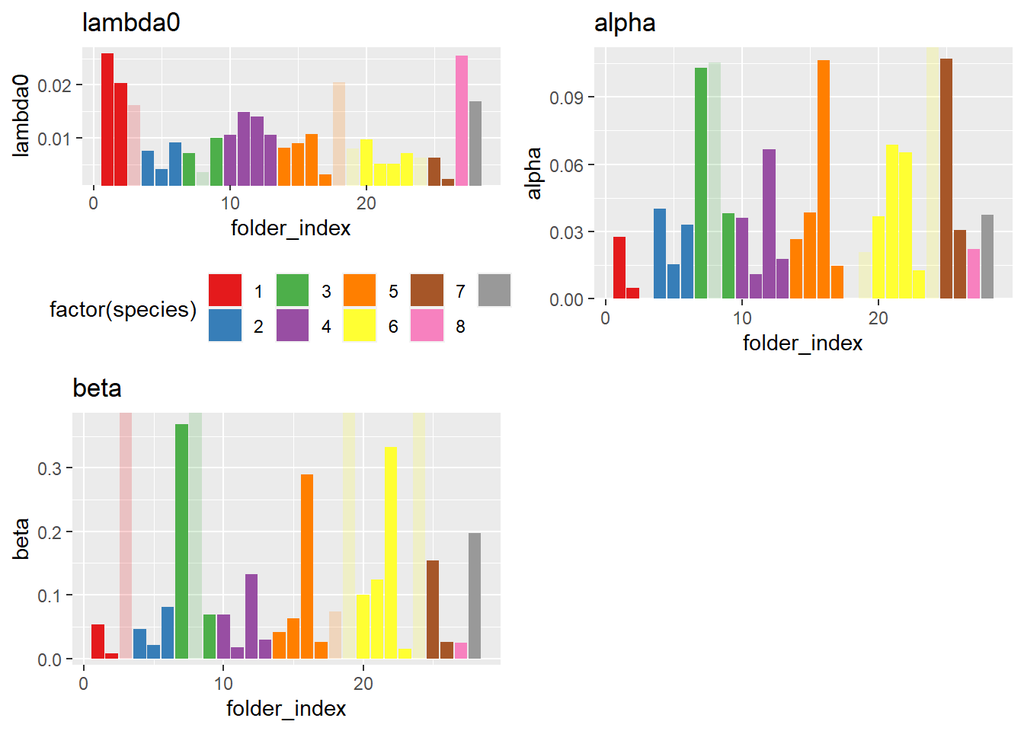

Change in P-values (Poisson vs Hawkes Process)

|  | folder_index | species | KS_pval_PP | KS_pval_HP | num_emb_img | converge_HP | incr_p_val |
| --- | --- | --- | --- | --- | --- | --- | --- |
| alclat2_stem | 1.00 | 1.00 | 0.01 | 0.40 | 80.00 | 1.00 | 0.39 |
| alclat4_stem | 2.00 | 1.00 | 0.06 | 0.24 | 134.00 | 1.00 | 0.18 |
| alclat5.2_stem | 3.00 | 1.00 | 0.97 | 0.86 | 8.00 | 1.00 | -0.11 |
| casarb2.2_stem | 4.00 | 2.00 | 0.00 | 0.13 | 45.00 | 1.00 | 0.13 |
| casarb4_stem | 5.00 | 2.00 | 0.00 | 0.96 | 37.00 | 1.00 | 0.96 |
| casarb5_stem | 6.00 | 2.00 | 0.01 | 0.89 | 41.00 | 1.00 | 0.88 |
| dacexc1_stem | 7.00 | 3.00 | 0.07 | 0.67 | 25.00 | 1.00 | 0.60 |
| dacexc3_stem | 8.00 | 3.00 | 0.85 | 0.55 | 8.00 | 1.00 | -0.30 |
| dacexc5.2_stem | 9.00 | 3.00 | 0.00 | 0.68 | 54.00 | 1.00 | 0.68 |
| drygla2_stem | 10.00 | 4.00 | 0.01 | 0.91 | 39.00 | 1.00 | 0.91 |
| drygla3.2_stem | 11.00 | 4.00 | 0.07 | 0.72 | 103.00 | 1.00 | 0.65 |
| drygla4_stem | 12.00 | 4.00 | 0.00 | 0.08 | 88.00 | 1.00 | 0.08 |
| drygla5_stem | 13.00 | 4.00 | 0.01 | 0.88 | 59.00 | 1.00 | 0.87 |
| inglau1_stem | 14.00 | 5.00 | 0.00 | 0.17 | 65.00 | 1.00 | 0.17 |
| inglau2_stem | 15.00 | 5.00 | 0.00 | 0.61 | 64.00 | 1.00 | 0.61 |
| inglau3_stem | 16.00 | 5.00 | 0.00 | 0.35 | 32.00 | 1.00 | 0.35 |
| inglau4_stem | 17.00 | 5.00 | 0.00 | 0.54 | 35.00 | 1.00 | 0.54 |
| inglau5_stem | 18.00 | 5.00 | 0.72 | 0.50 | 7.00 | 1.00 | -0.22 |
| micguy1_stem | 19.00 | 6.00 | 0.47 | 0.30 | 14.00 | 1.00 | -0.17 |
| micguy2_stem | 20.00 | 6.00 | 0.01 | 0.52 | 42.00 | 1.00 | 0.51 |
| micguy3_stem | 21.00 | 6.00 | 0.00 | 0.42 | 46.00 | 1.00 | 0.42 |
| micguy3b_stem | 22.00 | 6.00 | 0.17 | 0.90 | 29.00 | 1.00 | 0.73 |
| micguy4_stem | 23.00 | 6.00 | 0.00 | 0.77 | 93.00 | 1.00 | 0.77 |
| micguy5_stem | 24.00 | 6.00 | 0.46 | 0.96 | 12.00 | 1.00 | 0.51 |
| ocoleu1_stem | 25.00 | 7.00 | 0.00 | 0.05 | 58.00 | 1.00 | 0.05 |
| ocoleu2_stem | 26.00 | 7.00 | 0.00 | 0.24 | 37.00 | 1.00 | 0.24 |
| slober3_stem | 27.00 | 8.00 | 0.00 | 0.00 | 441.00 | 1.00 | 0.00 |
| tabhet1.2_stem | 28.00 | 9.00 | 0.03 | 0.53 | 76.00 | 1.00 | 0.50 |

*If the fitting didn’t converge, we’ll place 0 as place-holders for all the estimates for parameters, KS p-value, and KS statistic.*

As expected, the K-S p-value increases in most cases, as Hawkes process should have more flexibility than Poisson process. And for the cases where p-value doesn’t increase are the experiments with very few or extremely many embolized images. It probably just means that there’s more uncertainty.

## Spatiotemporal Hawkes Process (absolute location difference)

Let $s_1,..,s_n$ denote the event locations.

Conditional intensity:

$$\lambda(s,t) = \lambda_0 + \alpha \sum_{i:t_i < t} e^{-\beta(t-t_i)} e^{-\gamma|s-s_i|}$$

$\lambda_0,\alpha \geq 0$ and $\beta,\gamma > 0$

For every experiment, I normalized event locations ($s_i$) to [0,1].

Log-likelihood:

$$\begin{aligned}
l(t_1...,t_n, s_1,...,s_n) &= - \int_{0}^{t_n} \int_{0}^{1} \lambda(s,t) ds dt + \sum_{i=1}^{n} \log(\lambda(s_i,t_i)) \\
&= - \int_{0}^{t_n} [\int_{0}^{s_i} \lambda(s,t) ds + \int_{s_i}^{1} \lambda(s,t) ds ]dt + \sum_{i=1}^{n} \log(\lambda(s_i,t_i)) \\
&= - \int_{0}^{t_n} \lambda_0 + \alpha \sum_{i:t_i < t} e^{-\beta(t-t_i)}[\int_{0}^{s_i} e^{-\gamma|s-s_i|} ds + \int_{s_i}^{1} e^{-\gamma|s-s_i|} ds ]dt + \sum_{i=1}^{n} \log(\lambda(s_i,t_i)) \\
&= - \int_{0}^{t_n} \lambda_0 + \alpha \sum_{i:t_i < t} e^{-\beta(t-t_i)}[\int_{0}^{s_i} e^{-\gamma(s_i-s)} ds + \int_{s_i}^{1} e^{-\gamma(s-s_i)} ds ]dt + \sum_{i=1}^{n} \log(\lambda(s_i,t_i)) \\
&= - \int_{0}^{t_n} \lambda_0 + \alpha \sum_{i:t_i < t} e^{-\beta(t-t_i)}[e^{-\gamma s_i} \frac{1}{\gamma} (e^{\gamma s_i} - e^{\gamma * 0}) - \frac{1}{\gamma} (e^{-\gamma(1-s_i)} - 1)]dt + \sum_{i=1}^{n} \log(\lambda(s_i,t_i)) \\
&= -\lambda_0 t_n - \frac{\alpha}{\beta \gamma} \sum_{i=1}^{n} (e^{-\beta(t_n-t_i)}-1)(-2 + e^{-\gamma s_i} + e^{-\gamma(1-s_i)}) + \sum_{i=1}^{n} \log (\lambda_0 + \alpha \sum_{k:t_k < t_i} e^{-\beta(t_i-t_k)}e^{-\gamma|s_i-s_k|})
\end{aligned}$$

*Reference: A Review of Self-Exciting Spatio-Temporal Point Processes and Their Applications (2018) Eq(8)*

The durations of the estimated residual process:

$$\begin{aligned}
\Lambda(t_i,t_{i+1}) &= \int_{t_i}^{t_{i+1}} \int_{0}^{1} \lambda(s,t) ds dt\\
&= \int_{t_i}^{t_{i+1}} \lambda_0 dt + \alpha \int_{t_i}^{t_{i+1}} \int_{0}^{1} \sum_{k:t_k < t} e^{-\beta(t-t_k)} e^{-\gamma|s-s_k|} ds dt \\
&= \lambda_0 (t_{i+1} - t_i) + \alpha \sum_{k=1}^{i} \int_{t_i}^{t_{i+1}} e^{-\beta(t-t_k)} \int_{0}^{1} e^{-\gamma|s-s_k|} ds dt \\
&= \lambda_0 (t_{i+1} - t_i) - \frac{\alpha}{\gamma} \sum_{k=1}^{i} \int_{t_i}^{t_{i+1}} e^{-\beta(t-t_k)} (-2 + e^{-\gamma s_k} + e^{-\gamma(1-s_k)}) dt \\
&= \lambda_0 (t_{i+1} - t_i) + \frac{\alpha}{\beta \gamma} \sum_{k=1}^{i} (e^{-\beta(t_{i+1}-t_k)} - e^{-\beta(t_{i}-t_k)}) (-2 + e^{-\gamma s_k} + e^{-\gamma(1-s_k)})
\end{aligned}$$

In the reference below, it only mentioned that $\Lambda(t_i) = \int_{0}^{t_{i}} \int_{0}^{1} \lambda(s,t) ds dt$ would be a unit rate Poisson process. **So, the above might not necessarily follows unit rate exponential distribution.**

*Reference: A semi-parametric spatiotemporal Hawkes-type point process model with periodic background for crime data (2018)*

Pearson Residual:

$$\begin{aligned}
R_P(B_i) &= \sum_{(s_j,t_j)\in B_i} \frac{1}{\sqrt{{\lambda(s_j,t_j)}}} - \int_{B_i} \sqrt{\lambda(s,t)} dt ds
\end{aligned}$$

*Reference: Residual analysis methods for space-time point processes with applications to earthquake forecast models in California (2011) [the eq after Eq(1)]*

*Reference: Second-order residual analysis of spatiotemporal point processes and applications in model evaluation by Zhuang(2006)*

(I inferred the ones below…)

To compare with Temporal Hawkes Process Pearson Residual, let’s consider $B_i = [0,1] \times[0,t_i]$.

The Pearson residual in the time interval $(t_i,t_{i+1}]$:

$$\begin{aligned}
R_P(B_i) &= \sum_{j=1}^{i} \frac{1}{\sqrt{{\lambda(s_j,t_j)}}} - \int_{0}^{t_i} \int_{0}^{1} \sqrt{\lambda(s,t)} ds dt\\
r_{pearson}(t_i,t_{i+1}) &= \frac{1}{t_{i+1}-t_i}(R_P(B_{i+1}) - R_P(B_{i}))\\
&= \frac{1}{t_{i+1}-t_i}(\frac{1}{\sqrt{{\lambda(s_{i+1},t_{i+1})}}} - \int_{t_i}^{t_{i+1}} \int_{0}^{1}\sqrt{\lambda(s,t)} ds dt)
\end{aligned}$$

### Look at the fitted parameters of Spatial-Temporal Hawkes Process

```
##                folder_index species num_emb_img     lambda0       alpha
## alclat2_stem              1       1          80 0.011644599 0.373026673
## alclat4_stem              2       1         134 0.020089988 0.004386838
## alclat5.2_stem            3       1           8 0.016261076 0.000000000
## casarb2.2_stem            4       2          45 0.007098037 0.273519116
## casarb4_stem              5       2          37 0.001993424 0.153973361
## casarb5_stem              6       2          41 0.004214479 0.145889645
## dacexc1_stem              7       3          25 0.007160412 0.102295477
## dacexc3_stem              8       3           8 0.003637067 0.105814564
## dacexc5.2_stem            9       3          54 0.008512096 0.784519405
## drygla2_stem             10       4          39 0.007729620 0.106116739
## drygla3.2_stem           11       4         103 0.003427141 0.094215235
## drygla4_stem             12       4          88 0.016973924 3.222940571
## drygla5_stem             13       4          59 0.009276312 0.192705145
## inglau1_stem             14       5          65 0.004644470 0.095453495
## inglau2_stem             15       5          64 0.010632516 0.239866745
## inglau3_stem             16       5          32 0.010741836 1.095119488
## inglau4_stem             17       5          35 0.003093488 0.015198694
## inglau5_stem             18       5           7 0.020473109 0.000000000
## micguy1_stem             19       6          14 0.008015811 0.017667142
## micguy2_stem             20       6          42 0.011084725 0.491450106
## micguy3_stem             21       6          46 0.005901591 3.504792057
## micguy3b_stem            22       6          29 0.001137043 0.025808529
## micguy4_stem             23       6          93 0.003106582 0.111217036
## micguy5_stem             24       6          12 0.006249122 0.118702342
## ocoleu1_stem             25       7          58 0.006058351 0.559761894
## ocoleu2_stem             26       7          37 0.002306040 0.030568884
## slober3_stem             27       8         441 0.027485948 0.529055085
## tabhet1.2_stem           28       9          76 0.017168639 2.311068059
##                       beta        gamma converge not_few_emb
## alclat2_stem   0.034693045 2.663217e+01        1         1.0
## alclat4_stem   0.007097802 1.103613e-02        1         1.0
## alclat5.2_stem 1.017132353 1.507368e-02        1         0.2
## casarb2.2_stem 0.046612185 1.235448e+01        1         1.0
## casarb4_stem   0.011797720 2.539088e+01        1         1.0
## casarb5_stem   0.024713123 1.492359e+01        1         1.0
## dacexc1_stem   0.365969321 1.575465e-02        1         1.0
## dacexc3_stem   0.745822459 1.228900e-02        1         0.2
## dacexc5.2_stem 0.020889403 1.204375e+02        1         1.0
## drygla2_stem   0.026740872 1.118313e+01        1         1.0
## drygla3.2_stem 0.011060903 1.807794e+01        1         1.0
## drygla4_stem   0.147816938 1.097919e+02        1         1.0
## drygla5_stem   0.020838636 2.772678e+01        1         1.0
## inglau1_stem   0.013444529 1.719263e+01        1         1.0
## inglau2_stem   0.087201618 9.631195e+00        1         1.0
## inglau3_stem   0.234035247 2.390193e+01        1         1.0
## inglau4_stem   0.026097964 9.307542e-02        1         1.0
## inglau5_stem   0.072640120 1.057342e-02        1         0.2
## micguy1_stem   0.505835768 4.172057e-02        1         0.2
## micguy2_stem   0.346764520 1.048065e+01        1         1.0
## micguy3_stem   0.286933824 5.024593e+01        1         1.0
## micguy3b_stem  0.003433390 1.582941e+01        1         1.0
## micguy4_stem   0.010399937 2.230254e+01        1         1.0
## micguy5_stem   0.492154815 4.440671e-02        1         0.2
## ocoleu1_stem   0.154065254 9.879745e+00        1         1.0
## ocoleu2_stem   0.026503672 6.640613e-03        1         1.0
## slober3_stem   0.032934531 3.651066e+01        1         1.0
## tabhet1.2_stem 0.194630182 1.327336e+02        1         1.0
```

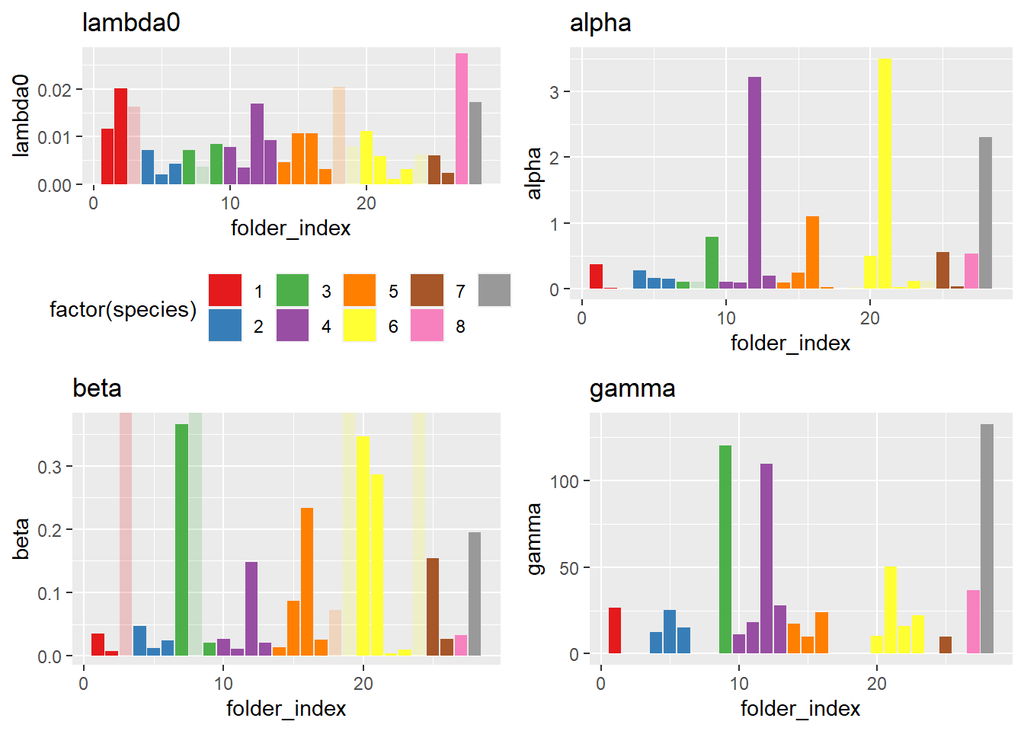

### Paired Samples T-test on Pearson Residuals of Two Models

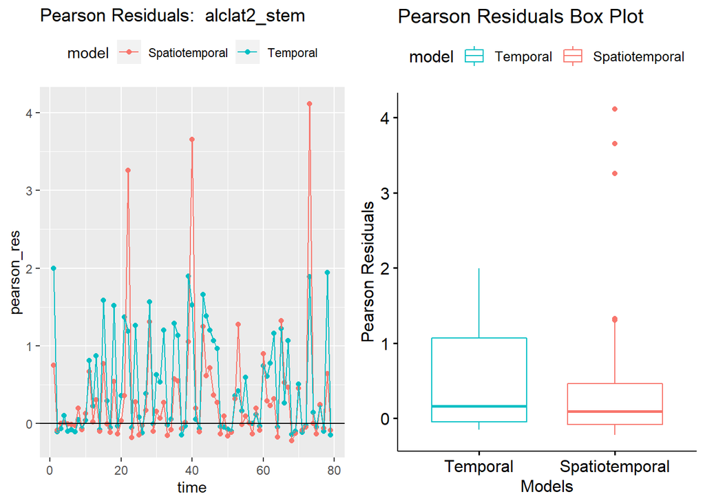

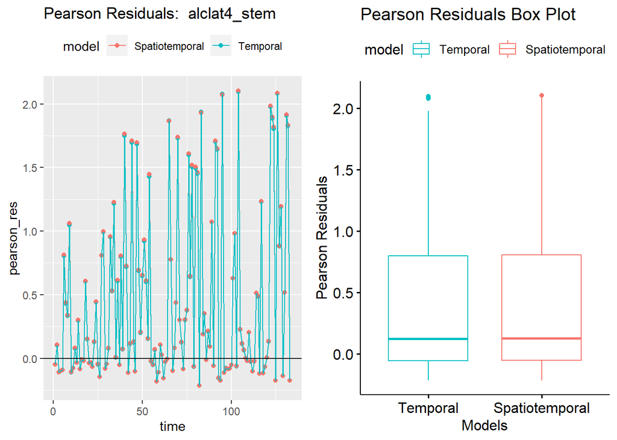

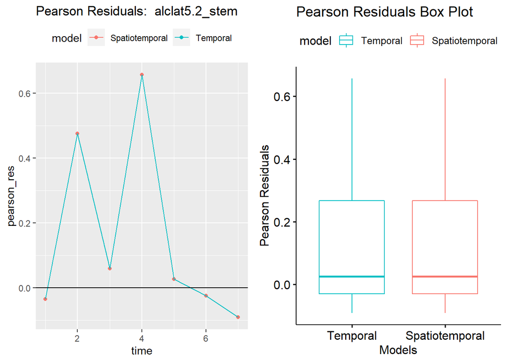

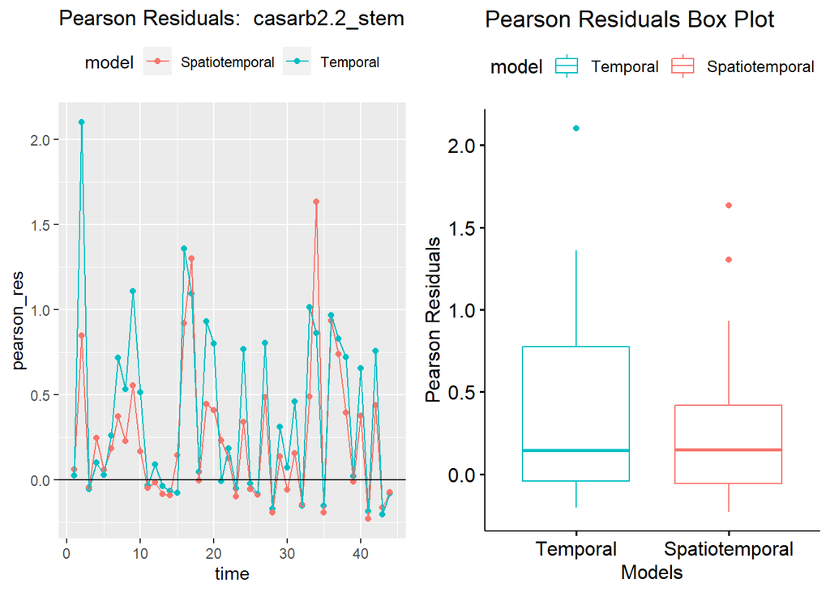